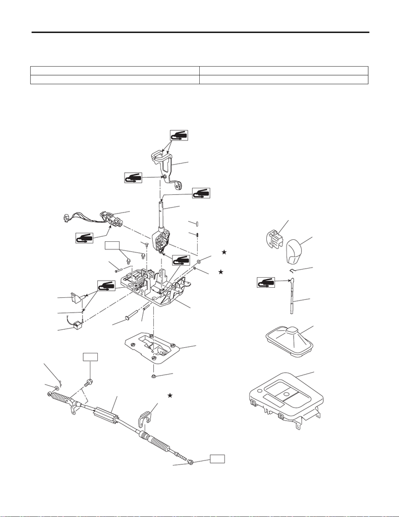

CS-2

General Description

CONTROL SYSTEMS

1. General Description

A: SPECIFICATION

B: COMPONENT

1. AT SELECT LEVER

Item Specifications

Swing torque of rod against lever N (kgf, lbf) 3.7 (0.38, 0.83) or less

T2

(10)

(8)

(9)

(11)

(12)

(13)

(14)

(15)

(16) (17)

(18)

(19)

(20)

(21)

T2

(22)

(23)

(25)

T1

(7)

(6)

(1)

(28)

(2)

(3)

(5)

(4)

(26)

(27)

(24)

CS-01826

[figure not shown]

CS-3

General Description

CONTROL SYSTEMS

(1) Grip sub ASSY (12) Clamp push nut (23) Snap pin

(2) Clamp grip pin (13) Clamp pin (24) Washer

(3) Rod COMPL (14) Spacer pin guide (25) Select cable

(4) Boot ASSY (15) Plate COMPL (26) Clamp

(5) Indicator ASSY (16) Shaft control (27) Nut

(6) Arm COMPL (17) Spacer pin guide (28) Button ASSY-AT

(7) Selector lever COMPL (18) Rod shift lock

(8) Plate guide (19) Cushion solenoid Tightening torque: N·m (kgf-m, ft-lb)

(9) Rod detent (20) Solenoid unit T1: 7.5 (0.8, 5.5)

(10) Detent spring (21) Gasket T2: 18 (1.8, 13.3)

(11) Clamp push nut (22) Spacer plate

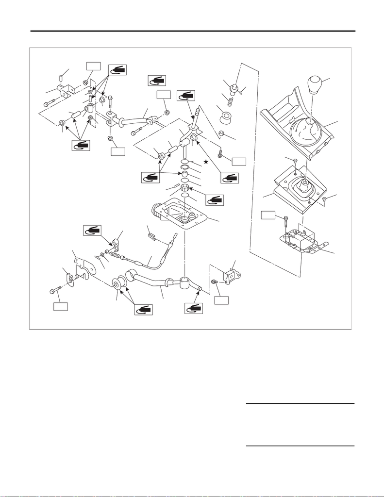

CS-4

General Description

CONTROL SYSTEMS

2. 6MT GEAR SHIFT LEVER (STI MODEL)

(1) Gear shift knob (15) Snap ring (29) Snap pin

(2) Cover - shift lever (16) Bushing (30) Bracket

(3) Boot and insulator ASSY (17) O-ring (31) Cable plate

(4) Clamp (18) Spring pin (32) Rod

(5) Plate COMPL (19) Bushing (33) Spring pin

(6) Slider (20) O-ring (34) Joint

(7) Spring pin (21) Boot (35) Boss

(8) Spring (22) Cushion rubber

(9) Holder (23) Stay Tightening torque: N·m (kgf-m, ft-lb)

(10) Seat cushion (24) Bushing T1: 1.3 (0.1, 1.0)

(11) Lever (25) Reverse check cable T2: 12 (1.2, 8.9)

(12) Bushing (26) Band clip T3: 18 (1.8, 13.3)

(13) Spacer (27) Reverse check lever T4: 32 (3.3, 23.6)

(14) Lock wire (28) Washer

T3

T4

(5)

(4)

(6)

(3)

(2)

(1)

(23)

(24)

(25)

(19)

(20)

(21)

(22)

(18)

(17)

(16)

(13)

(15)

(14)

(12)

(11)

(28)

(30)

(29)

(10)

(9)

(8)

(27)

(26)

(31)

(32)

CS-01775

(7)

(4)

(33)

(34)

(35)

(12)

(12)

(12)

(12)

(12)

(13)

(13)

T1

T2

T3

T2

T2

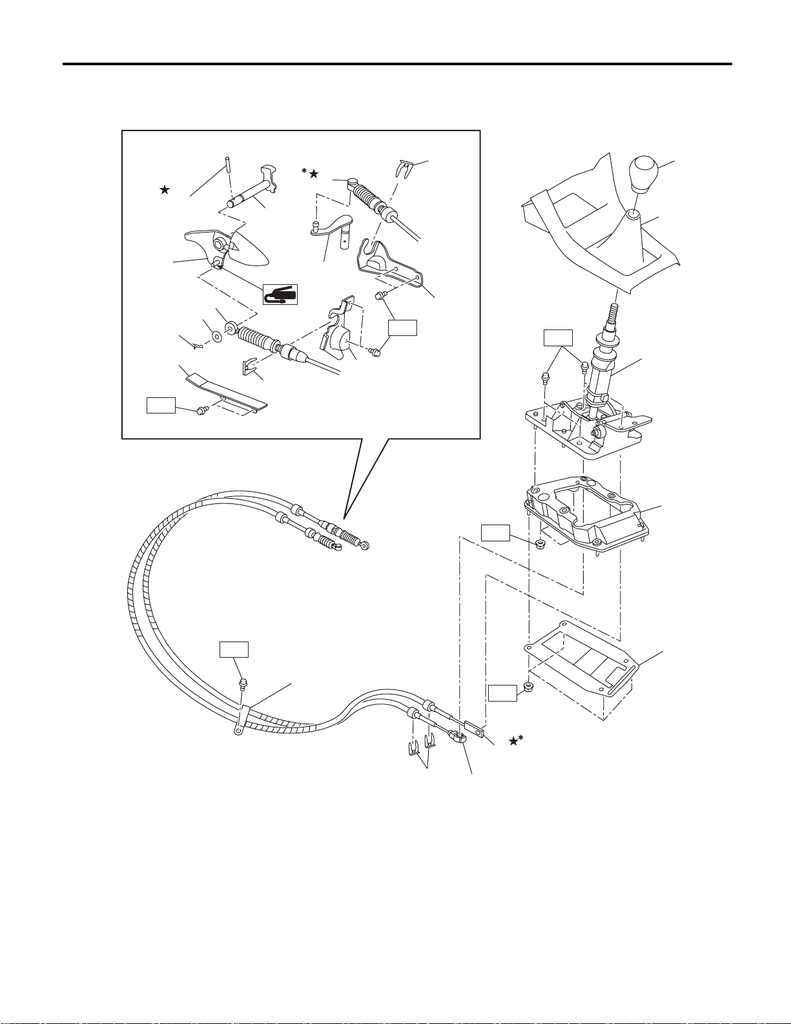

CS-5

General Description

CONTROL SYSTEMS

3. 6MT GEAR SHIFT LEVER (EXCEPT FOR STI MODEL)

CS-01846

(1)

T2

(7)

(8)

T1

(3)

(4)

T3

(5)

(6)

(9)

T1

(7)

(16)

(15)

(17)

(13)

(11)

(10)

(6)

T3

T2

(18)

(14)

(8)

(8)

(2)

(12)

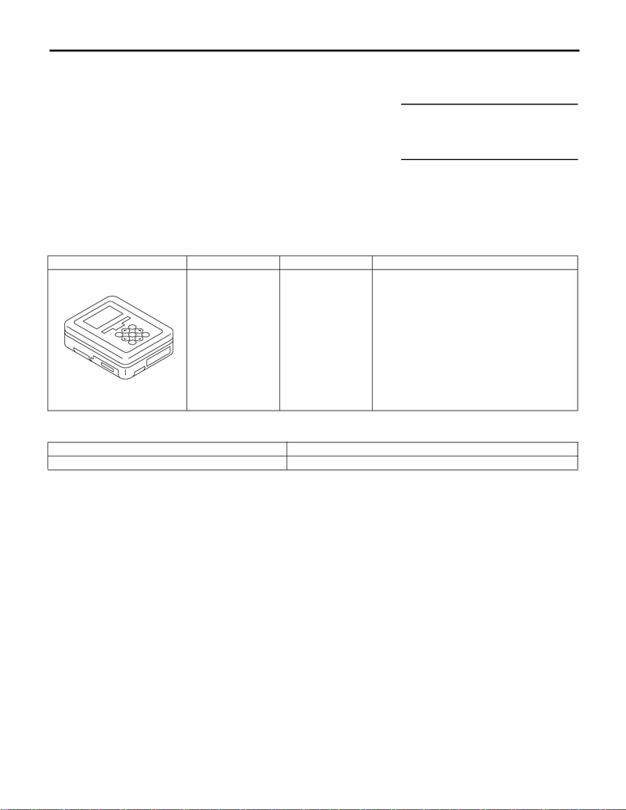

CS-6

General Description

CONTROL SYSTEMS

*: Always use new MT gear select cable if the cable is removed from select lever COMPL of transmission

side.

C: PREPARATION TOOL

1. SPECIAL TOOL

2. GENERAL TOOL

D: CAUTION

• Remove contamination including dirt and corrosion before removal, installation or disassembly.

• Keep the disassembled parts in order and protect them from dust and dirt.

• Before removal, installation or disassembly, be sure to clarify the failure. Avoid unnecessary removal, in-

stallation, disassembly and replacement.

• Use SUBARU genuine fluid, grease etc. or equivalent. Do not mix fluid, grease, etc. of different grades or

manufacturers.

• Be sure to tighten fasteners including bolts and nuts to the specified torque.

• Apply grease onto sliding or revolving surfaces before installation.

• Before installing O-rings or snap rings, apply a proper amount of grease to avoid damage and deformation.

• Before securing a part in a vise, place cushioning material such as wood blocks, aluminum plate or cloth

between the part and the vise.

• Before disconnecting electrical connectors, be sure to disconnect the negative terminal from battery.

(1) Shift knob (9) Cable clamp (17) Select bracket

(2) Cover - shift lever (10) Dust cover (18) Shift bracket

(3) Gear shift lever ASSY (11) Snap pin

(4) Cable cover ASSY (12) Washer Tightening torque: N·m (kgf-m, ft-lb)

(5) Cable cover plate (13) Shift lever COMPL T1: 7.5 (0.8, 5.5)

(6) MT gear select cable (14) Spring pin T2: 15 (1.5, 11.1)

(7) MT gear shift cable (15) Shifter arm No. 2 T3: 18 (1.8, 13.3)

(8) Clamp (16) Selector lever COMPL

ILLUSTRATION TOOL NUMBER DESCRIPTION REMARKS

1B022XU0 SUBARU SELECT

MONITOR III KIT

Used for troubleshooting the electrical system.

TOOL NAME REMARKS

Circuit tester Used for measuring resistance and voltage.

ST1B022XU0